# Group21_drone_data_training

```python
"""
Object detection on the drone data set using Mask R-CNN

Code adapted from MaskRCNN/balloon.py and run_prediction_fromChopped.ipynb

Group21
Mingyong Liu, Emmanuel Obi, Pat Ganesan and Dipak Dulal
"""
```

[output not shown]

```python
from google.colab import drive
drive.mount('/content/drive')
```

## **Install packages and set up**

```python
#import packages
import os
import sys
import json
import numpy as np
import skimage.draw
import matplotlib.pyplot as plt
import pickle


%cd "/content/drive/My Drive/machine_learning_project"
ROOT_DIR = os.getcwd()
print(ROOT_DIR)
```

```
/content/drive/My Drive/machine_learning_project
/content/drive/My Drive/machine_learning_project
```

```python
#install Mask_RCNN (needed for the first time)
#!git clone https://github.com/akTwelve/Mask_RCNN.git aktwelve_mask_rcnn
```

[output not shown]

```python
%cd "/content/drive/MyDrive/machine_learning_project/aktwelve_mask_rcnn"
#!pip install -r requirements.txt
#!python setup.py clean --all install
```

```
/content/drive/MyDrive/machine_learning_project/aktwelve_mask_rcnn
```

```python
# Import Mask RCNN
from mrcnn import utils
import mrcnn.model as modellib
from mrcnn import visualize
from mrcnn.config import Config
```

```python
# Check if GPU is used. If not, go to the 'Edit' -> Notebook setting
import tensorflow as tf
device_name = tf.test.gpu_device_name()
if device_name != '/device:GPU:0':
  raise SystemError('GPU device not found')
print('Found GPU at: {}'.format(device_name))
```

```
Found GPU at: /device:GPU:0
```

## To perform transfer training, we utilized pre-trained weights from COCO first. The code below import COCO pre-trained weights

```python
# Path to trained weights file
COCO_WEIGHTS_PATH = os.path.join(ROOT_DIR, "mask_rcnn_coco.h5")
# Download COCO trained weights from Releases if needed
if not os.path.exists(COCO_WEIGHTS_PATH):
    utils.download_trained_weights(COCO_WEIGHTS_PATH)


# Directory to save logs and model checkpoints, if not provided
# through the command line argument --logs
DEFAULT_LOGS_DIR = os.path.join(ROOT_DIR, "logs")
```

Code below sets up the configurations for training and testing. The number of classes was set to 6 because we have 5 classes plus 1 background. The STEPS_PER_EPOCH was set to 150, and ResNet50 backbone was used. The other parameters were kept the same as the solution provided by Dr. Yan.

```python
############################################################
#  Configurations
############################################################
class DroneConfig(Config):
    """Configuration for training on the Drone dataset.
    Derives from the base Config class and overrides some values.
    """
    # Give the configuration a recognizable name
    NAME = "drone_cfg"

   # number of classes (background + others)
    NUM_CLASSES = 1 + 5
    # number of training steps per epoch
    GPU_COUNT = 1
    IMAGES_PER_GPU = 1
    STEPS_PER_EPOCH=150
    ###################################################################################
    BACKBONE = "resnet50"
    #BACKBONE = "resnet101"

    #Turn off the USE_MINI_MASK (Important!!)
    USE_MINI_MASK = False


    # Length of square anchor side in pixels
    RPN_ANCHOR_SCALES = (16, 32, 64, 128, 256)

    # Non-max suppression threshold to filter RPN proposals.
    # You can increase this during training to generate more propsals.
    RPN_NMS_THRESHOLD = 0.6

    # How many anchors per image to use for RPN training
    RPN_TRAIN_ANCHORS_PER_IMAGE = 512

    # Percent of positive ROIs used to train classifier/mask heads
    ROI_POSITIVE_RATIO = 0.6

#     IMAGE_MIN_DIM = 512
#     IMAGE_MAX_DIM = 1024

    # Number of ROIs per image to feed to classifier/mask heads
    # The Mask RCNN paper uses 512 but often the RPN doesn't generate
    # enough positive proposals to fill this and keep a positive:negative
    # ratio of 1:3. You can increase the number of proposals by adjusting
    # the RPN NMS threshold.
    TRAIN_ROIS_PER_IMAGE = 512

    # Max number of final detections
    DETECTION_MAX_INSTANCES = 100

    # Minimum probability value to accept a detected instance
    # ROIs below this threshold are skipped
    DETECTION_MIN_CONFIDENCE = 0.7

    # Non-maximum suppression threshold for detection
    DETECTION_NMS_THRESHOLD = 0.4
    pass


config = DroneConfig()
config.display()
```

```
Configurations:
BACKBONE                       resnet50
BACKBONE_STRIDES               [4, 8, 16, 32, 64]
BATCH_SIZE                     1
BBOX_STD_DEV                   [0.1 0.1 0.2 0.2]
COMPUTE_BACKBONE_SHAPE         None
DETECTION_MAX_INSTANCES        100
DETECTION_MIN_CONFIDENCE       0.7
DETECTION_NMS_THRESHOLD        0.4
FPN_CLASSIF_FC_LAYERS_SIZE     1024
GPU_COUNT                      1
GRADIENT_CLIP_NORM             5.0
IMAGES_PER_GPU                 1
IMAGE_CHANNEL_COUNT            3
IMAGE_MAX_DIM                  1024
IMAGE_META_SIZE                18
IMAGE_MIN_DIM                  800
IMAGE_MIN_SCALE                0
IMAGE_RESIZE_MODE              square
IMAGE_SHAPE                    [1024 1024    3]
LEARNING_MOMENTUM              0.9
LEARNING_RATE                  0.001
LOSS_WEIGHTS                   {'rpn_class_loss': 1.0, 'rpn_bbox_loss': 1.0, 'mrcnn_class_loss': 1.0, 'mrcnn_bbox_loss': 1.0, 'mrcnn_mask_loss': 1.0}
MASK_POOL_SIZE                 14
MASK_SHAPE                     [28, 28]
MAX_GT_INSTANCES               100
MEAN_PIXEL                     [123.7 116.8 103.9]
MINI_MASK_SHAPE                (56, 56)
NAME                           drone_cfg
NUM_CLASSES                    6
POOL_SIZE                      7
POST_NMS_ROIS_INFERENCE        1000
POST_NMS_ROIS_TRAINING         2000
PRE_NMS_LIMIT                  6000
ROI_POSITIVE_RATIO             0.6
RPN_ANCHOR_RATIOS              [0.5, 1, 2]
RPN_ANCHOR_SCALES              (16, 32, 64, 128, 256)
RPN_ANCHOR_STRIDE              1
RPN_BBOX_STD_DEV               [0.1 0.1 0.2 0.2]
RPN_NMS_THRESHOLD              0.6
RPN_TRAIN_ANCHORS_PER_IMAGE    512
STEPS_PER_EPOCH                150
TOP_DOWN_PYRAMID_SIZE          256
TRAIN_BN                       False
TRAIN_ROIS_PER_IMAGE           512
USE_MINI_MASK                  False
USE_RPN_ROIS                   True
VALIDATION_STEPS               50
WEIGHT_DECAY                   0.0001
```

Code below creates a DroneDataset class by inheriting the utils.Dataset class. The first function load_drone_data takes in pictures and their associated VIA annotations. The second and third functions draw a box and polygon mask according to annotations, respectively.

```python
############################################################
#  Dataset
############################################################

class DroneDataset(utils.Dataset):

    def load_drone_data(self, dataset_dir, subset):
        """Load the Drone dataset.
        dataset_dir: Root directory of the dataset.
        subset: Subset to load: train or val
        """
        # define one class
        self.add_class("classes", 1, "Head")
        self.add_class("classes", 2, "Thread")
        self.add_class("classes", 3, "Nut")
        self.add_class("classes", 4, "Washer")
        self.add_class("classes", 5, "Pin")


        # define data locations
        images_dir = dataset_dir
        image_files = [file for file in os.listdir(images_dir) if file.endswith('.jpg')]
        image_num = len(image_files)

        # Split data into training, testing and validation data subsets at a 0.7:0.15:0.15 ratio
        assert subset in ['Train','Test','Val']
        if subset == 'Train':
            image_ids = image_files[:int(0.7 * image_num)]
        elif subset == 'Val':
            image_ids = image_files[int(0.7 * image_num):int(0.85 * image_num)]
        elif subset == 'Test':
            image_ids = image_files[int(0.95 * image_num):]

        # Load annotations
        # VGG Image Annotator saves each image in the form:
        # { 'filename': '28503151_5b5b7ec140_b.jpg',
        #   'regions': {
        #       '0': {
        #           'region_attributes': {},
        #           'shape_attributes': {
        #               'all_points_x': [...],
        #               'all_points_y': [...],
        #               'name': 'polygon'}},
        #       ... more regions ...
        #   },
        #   'size': 100202
        # }

        # Extract the x and y coordinates of each region
        annotations = json.load(open(os.path.join(dataset_dir, "new_HQ_annotations.json")))
        annotations = list(annotations.values())  # don't need the dict keys

        # Extract the information from JSON file according to the data subset
        annotations = [a for a in annotations if (a['filename'] in image_ids)]


        # Add images
        for a in annotations:
            # Get the x, y coordinaets of points of the polygons that make up
            # the outline of each object instance.

            polygons = [r['shape_attributes'] for r in a['regions']]

            #class is saved in region_attributes
            classes = [r['region_attributes']['class'] for r in a['regions']]

            # load_mask() needs the image size to convert polygons to masks
            image_path = os.path.join(dataset_dir, a['filename'])
            image = skimage.io.imread(image_path)
            height, width = image.shape[:2]

            self.add_image(
                "classes",
                image_id=a['filename'],  # use file name as a unique image id
                classes = classes,
                path=image_path,
                width=width, height=height,
                polygons=polygons)

    def extract_boxes(self, image_id):
        info = self.image_info[image_id]
        return info['polygons'], info['width'], info['height']

    # load the masks for an image
    def load_mask(self, image_id):
        boxes, w, h = self.extract_boxes(image_id)
        #print(boxes)

        # create one array for all masks, each on a different channel
        image_info = self.image_info[image_id]
        masks = np.zeros([h, w, len(boxes)], dtype='uint8')
        # create masks
        class_ids = list()
        regions = image_info['polygons']
        for i,r in enumerate(regions):
            #class_label = r['region_attributes']['class']
            class_label = image_info['classes'][i]
            shape = r
            assert (shape['name'] == 'polygon'), 'Shape is not polygon but ' + shape['name']
            all_points_x = shape['all_points_x']
            all_points_y = shape['all_points_y']
            assert (len(all_points_x) == len(all_points_y)), 'all_points_x != all_points_y'
            rr, cc = skimage.draw.polygon(all_points_y, all_points_x)
            masks[rr, cc, i] = 1
            class_ids.append(self.class_names.index(class_label))
        return masks, np.asarray(class_ids, dtype='int32')
```

## **Training**

```python
# Training dataset
train_set = DroneDataset()
train_folder = "/content/drive/My Drive/machine_learning_project/split_pictures_112620/"
train_set.load_drone_data(train_folder, subset='Train')
train_set.prepare()
print('train: %d' % len(train_set.image_ids))
```

```
train: 5628
```

```python
# Validation dataset
val_set = DroneDataset()
val_folder = "/content/drive/My Drive/machine_learning_project/split_pictures_112620/"
val_set.load_drone_data(val_folder, subset = "Val")
val_set.prepare()
print('val: %d' % len(val_set.image_ids))
```

```
val: 1206
```

```python
#Create a model for training
model = modellib.MaskRCNN(mode="training", config=config, model_dir = DEFAULT_LOGS_DIR)
```

```python
#initiate the model with COCO pre-trained weights
model.load_weights(COCO_WEIGHTS_PATH, by_name=True,
                   exclude=["mrcnn_class_logits", "mrcnn_bbox_fc", "mrcnn_bbox", "mrcnn_mask"])
```

After weights from the pre-trained model (COCO) were loaded, we performed transfer training. This is needed because the original COCO data set does not have items that we are going to detect (such as Header, Washer etc). Our training strategy was to first train the classifier (layers='heads') of a model while freezing all other layers, then train the other layers (layers='all'). The readouts that we used to determine the performance of a model were 'loss' and 'val_loss'. After trying numerous settings for epochs and learning_rate, we constantly found that the loss was lower when we only trained the heads.

Code below is an example setting that we tried, wherein we tried the heads for 60 epoches using the default learning rate (0.001)

```python
# Train the head branches
# Passing layers="heads" freezes all layers except the head layers.
model.train(train_set, val_set,
            learning_rate=config.LEARNING_RATE,
            epochs= 60,
            layers='heads')

# Train the 4+ layer
#model.train(train_set, val_set,
#            learning_rate=config.LEARNING_RATE,
#            epochs= 60,
#            layers='4+')

#Train the body
#model.train(train_set, val_set,
#            learning_rate=config.LEARNING_RATE / 10,
#           epochs= 80,
#            layers='all')
```

```
Starting at epoch 0. LR=0.001

Checkpoint Path: /content/drive/My Drive/machine_learning_project/logs/drone_cfg20201202T2058/mask_rcnn_drone_cfg_{epoch:04d}.h5
Selecting layers to train
fpn_c5p5               (Conv2D)
fpn_c4p4               (Conv2D)
fpn_c3p3               (Conv2D)
fpn_c2p2               (Conv2D)
fpn_p5                 (Conv2D)
fpn_p2                 (Conv2D)
fpn_p3                 (Conv2D)
fpn_p4                 (Conv2D)
rpn_model              (Functional)
mrcnn_mask_conv1       (TimeDistributed)
mrcnn_mask_bn1         (TimeDistributed)
mrcnn_mask_conv2       (TimeDistributed)
mrcnn_mask_bn2         (TimeDistributed)
mrcnn_class_conv1      (TimeDistributed)
mrcnn_class_bn1        (TimeDistributed)
mrcnn_mask_conv3       (TimeDistributed)
mrcnn_mask_bn3         (TimeDistributed)
mrcnn_class_conv2      (TimeDistributed)
mrcnn_class_bn2        (TimeDistributed)
mrcnn_mask_conv4       (TimeDistributed)
mrcnn_mask_bn4         (TimeDistributed)
mrcnn_bbox_fc          (TimeDistributed)
mrcnn_mask_deconv      (TimeDistributed)
mrcnn_class_logits     (TimeDistributed)
mrcnn_mask             (TimeDistributed)
```

```
Instructions for updating:
This property should not be used in TensorFlow 2.0, as updates are applied automatically.
```

```python
#visualize the epoch loss
%load_ext tensorboard
#point tensorboard to where all the weight (h5) files are
%tensorboard --logdir="/content/drive/MyDrive/machine_learning_project/logs/drone_20201202_headonly"
```

## **Detection from test data set**

```python
#inference mode
model = modellib.MaskRCNN(mode="inference", config=config, model_dir=DEFAULT_LOGS_DIR)


# load the weight file of a model with the lowest loss
model_path = os.path.join(ROOT_DIR, "drone_weights_120120.h5")
print("Loading weights from ", model_path)
model.load_weights(model_path, by_name=True)
```

```
WARNING:tensorflow:From /usr/local/lib/python3.6/dist-packages/tensorflow/python/util/deprecation.py:574: calling map_fn_v2 (from tensorflow.python.ops.map_fn) with dtype is deprecated and will be removed in a future version.
Instructions for updating:
Use fn_output_signature instead
Loading weights from  /content/drive/My Drive/machine_learning_project/drone_weights_120120.h5
```

After loading the weights, we used the new model to detect items from test dataset

```python
# Create Test dataset
test_set = DroneDataset()
test_folder = "/content/drive/My Drive/machine_learning_project/split_pictures_112620/"
test_set.load_drone_data(test_folder, subset = "Test")
test_set.prepare()
```

```python
#Run detection on test data

results = []
APs_50 = {}
APs_75 = {}
APs_90 = {}
ARs_50 = {}
ARs_75 = {}
ARs_90 = {}

for image_id in test_set.image_ids:
    print('image_id =', image_id)

    #Load the ground truth pictures
    image, image_meta, gt_class_id, gt_bbox, gt_mask =\
    modellib.load_image_gt(test_set, config, image_id)

    #run detection using our model
    res = model.detect([image], verbose=0)[0]
    results.append(res)

    #calculate average precision (AP) at different iou thresholds
    AP_50, precisions, recalls, overlaps =\
    utils.compute_ap(gt_bbox, gt_class_id, gt_mask, res['rois'], res['class_ids'], res['scores'], res['masks'], iou_threshold=0.5)
    APs_50[image_id] = AP_50

    AP_75, precisions, recalls, overlaps =\
    utils.compute_ap(gt_bbox, gt_class_id, gt_mask, res['rois'], res['class_ids'], res['scores'], res['masks'], iou_threshold=0.75)
    APs_75[image_id] = AP_75

    AP_90, precisions, recalls, overlaps =\
    utils.compute_ap(gt_bbox, gt_class_id, gt_mask, res['rois'], res['class_ids'], res['scores'], res['masks'], iou_threshold=0.90)
    APs_90[image_id] = AP_90

    #calculate average recall (AR) at different iou thresholds
    AR_50, _ = utils.compute_recall(res['rois'], gt_bbox, iou = 0.5)
    ARs_50[image_id] = AR_50

    AR_75, _ = utils.compute_recall(res['rois'], gt_bbox, iou = 0.75)
    ARs_75[image_id] = AR_75

    AR_90, _ = utils.compute_recall(res['rois'], gt_bbox, iou = 0.90)
    ARs_90[image_id] = AR_90
```

[output not shown]

[output cut: 347 more lines]

[output not shown]

```python
#Average precisions
print('mAP_iou0.50 =',np.mean(list(APs_50.values())))
print('mAP_iou0.75 =',np.mean(list(APs_75.values())))
print('mAP_iou0.90 =',np.mean(list(APs_90.values())))
```

```
mAP_iou0.50 = 0.26097590421068684
mAP_iou0.75 = 0.05198107030425739
mAP_iou0.90 = 0.0008820425237144404
```

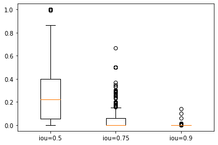

```python
#plot the Average precisions
plt.boxplot([list(APs_50.values()),list(APs_75.values()),list(APs_90.values())])
plt.xticks([1, 2, 3], ['iou=0.5', 'iou=0.75', 'iou=0.9'])
plt.show()
```

```python
#Rank the img id based on average precisions at iou_threshold = 0.5
rank = sorted(APs_50.items(), key = lambda x: x[1], reverse = True)
print(rank[0:15])
```

```
[(1, 1.0), (28, 1.0), (41, 1.0), (70, 1.0), (85, 1.0), (131, 1.0), (263, 1.0), (269, 1.0), (283, 1.0), (307, 0.9935897451180679), (126, 0.8642857032162803), (254, 0.8571428571428571), (321, 0.8399999797344208), (326, 0.8333333134651184), (129, 0.8237548139360216)]
```

```python
#Average recall
print('mAR_iou0.50 =',np.mean(list(ARs_50.values())))
print('mAR_iou0.75 =',np.mean(list(ARs_75.values())))
print('mAR_iou0.90 =',np.mean(list(ARs_90.values())))
```

```
mAR_iou0.50 = 0.444900637585468
mAR_iou0.75 = 0.13637837360963057
mAR_iou0.90 = 0.010543140869907664
```

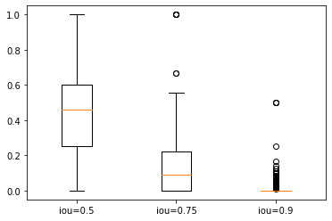

```python
#plot the Average recall
plt.boxplot([list(ARs_50.values()),list(ARs_75.values()),list(ARs_90.values())])
plt.xticks([1, 2, 3], ['iou=0.5', 'iou=0.75', 'iou=0.9'])
plt.show()
```